# in class activity week 8

Andrew McCartney

October 16, 2018

## EDLF 8360 In-class exercise 5

**In Canvas, go to Files, In-class exercises, and download ‘hsb.dta’. The ‘hsb’dta’ dataset comes from the High School and Beyond survey.**

```r
data(hsb)
hsb
```

| minority | female | ses | mathach | size | sector | pracad | disclim | himinty | schoolid | mean | sd | sdalt | junk | sdalt2 | num | se | sealt | sealt2 | t2 | t2alt | pickone | mmses | mnses | xb | resid |
| --- | --- | --- | --- | --- | --- | --- | --- | --- | --- | --- | --- | --- | --- | --- | --- | --- | --- | --- | --- | --- | --- | --- | --- | --- | --- |
| 0 | 1 | -1.528 | 5.876 | 842 | 0 | 0.35 | 1.597 | 0 | 1224 | 9.715446 | 7.592785 | 6.256328 | 4.571077e+01 | 48.39363 | 47 | 1.1075215 | 0.9125792 | 1.0147176 | 6.958498e+00 | 8.289523e+00 | 1 | -0.434382975 | -0.434382975 | 10.137589 | -4.261589e+00 |
| 0 | 1 | -0.588 | 19.708 | 842 | 0 | 0.35 | 1.597 | 0 | 1224 | 9.715446 | 7.592785 | 6.256328 | 4.999941e+01 | 48.39363 | 47 | 1.1075215 | 0.9125792 | 1.0147176 | 6.958498e+00 | 8.289523e+00 | 0 | -0.434382975 | -0.434382975 | 10.137589 | 9.570412e+00 |
| 0 | 0 | -0.528 | 20.349 | 842 | 0 | 0.35 | 1.597 | 0 | 1224 | 9.715446 | 7.592785 | 6.256328 | 5.947536e+01 | 48.39363 | 47 | 1.1075215 | 0.9125792 | 1.0147176 | 6.958498e+00 | 8.289523e+00 | 0 | -0.434382975 | -0.434382975 | 10.137589 | 1.021141e+01 |
| 0 | 0 | -0.668 | 8.781 | 842 | 0 | 0.35 | 1.597 | 0 | 1224 | 9.715446 | 7.592785 | 6.256328 | 1.486853e+01 | 48.39363 | 47 | 1.1075215 | 0.9125792 | 1.0147176 | 6.958498e+00 | 8.289523e+00 | 0 | -0.434382975 | -0.434382975 | 10.137589 | -1.356588e+00 |
| 0 | 0 | -0.158 | 17.898 | 842 | 0 | 0.35 | 1.597 | 0 | 1224 | 9.715446 | 7.592785 | 6.256328 | 2.767840e+01 | 48.39363 | 47 | 1.1075215 | 0.9125792 | 1.0147176 | 6.958498e+00 | 8.289523e+00 | 0 | -0.434382975 | -0.434382975 | 10.137589 | 7.760412e+00 |
| 0 | 0 | 0.022 | 4.583 | 842 | 0 | 0.35 | 1.597 | 0 | 1224 | 9.715446 | 7.592785 | 6.256328 | 6.486649e+01 | 48.39363 | 47 | 1.1075215 | 0.9125792 | 1.0147176 | 6.958498e+00 | 8.289523e+00 | 0 | -0.434382975 | -0.434382975 | 10.137589 | -5.554588e+00 |
| 0 | 1 | -0.618 | -2.832 | 842 | 0 | 0.35 | 1.597 | 0 | 1224 | 9.715446 | 7.592785 | 6.256328 | 2.392892e+02 | 48.39363 | 47 | 1.1075215 | 0.9125792 | 1.0147176 | 6.958498e+00 | 8.289523e+00 | 0 | -0.434382975 | -0.434382975 | 10.137589 | -1.296959e+01 |
| 0 | 0 | -0.998 | 0.523 | 842 | 0 | 0.35 | 1.597 | 0 | 1224 | 9.715446 | 7.592785 | 6.256328 | 1.467484e+02 | 48.39363 | 47 | 1.1075215 | 0.9125792 | 1.0147176 | 6.958498e+00 | 8.289523e+00 | 0 | -0.434382975 | -0.434382975 | 10.137589 | -9.614589e+00 |
| 0 | 1 | -0.888 | 1.527 | 842 | 0 | 0.35 | 1.597 | 0 | 1224 | 9.715446 | 7.592785 | 6.256328 | 1.234315e+02 | 48.39363 | 47 | 1.1075215 | 0.9125792 | 1.0147176 | 6.958498e+00 | 8.289523e+00 | 0 | -0.434382975 | -0.434382975 | 10.137589 | -8.610588e+00 |
| 0 | 0 | -0.458 | 21.521 | 842 | 0 | 0.35 | 1.597 | 0 | 1224 | 9.715446 | 7.592785 | 6.256328 | 7.892593e+01 | 48.39363 | 47 | 1.1075215 | 0.9125792 | 1.0147176 | 6.958498e+00 | 8.289523e+00 | 0 | -0.434382975 | -0.434382975 | 10.137589 | 1.138341e+01 |

[output cut: 7175 more lines]

**The variables in this dataset include:**

- schoolid - school identifier
- mathach - a measure of mathematics achievement
- ses - socioeconomic status based on parental education, occupation, & income
- sector - a 0/1 variable for whether a school was public or private

**1) Create a L2 variable for each school’s mean ses and a L1 variable for each student’s deviation around their school’s mean**

```r
hsb %>%
  group_by(schoolid) %>%
  mutate(sch_m_ses = mean(ses) ) %>%
  center(ses, mean(ses)) %>%
  head()
```

| minority | female | ses | mathach | size | sector | pracad | disclim | himinty | schoolid | mean | sd | sdalt | junk | sdalt2 | num | se | sealt | sealt2 | t2 | t2alt | pickone | mmses | mnses | xb | resid | sch_m_ses |
| --- | --- | --- | --- | --- | --- | --- | --- | --- | --- | --- | --- | --- | --- | --- | --- | --- | --- | --- | --- | --- | --- | --- | --- | --- | --- | --- |
| 0 | 1 | -1.09361702 | 5.876 | 842 | 0 | 0.35 | 1.597 | 0 | 1224 | 9.715446 | 7.592785 | 6.256328 | 45.71077 | 48.39363 | 47 | 1.107522 | 0.9125792 | 1.014718 | 6.958498 | 8.289523 | 1 | -0.434383 | -0.434383 | 10.13759 | -4.261589 | -0.434383 |
| 0 | 1 | -0.15361702 | 19.708 | 842 | 0 | 0.35 | 1.597 | 0 | 1224 | 9.715446 | 7.592785 | 6.256328 | 49.99941 | 48.39363 | 47 | 1.107522 | 0.9125792 | 1.014718 | 6.958498 | 8.289523 | 0 | -0.434383 | -0.434383 | 10.13759 | 9.570412 | -0.434383 |
| 0 | 0 | -0.09361702 | 20.349 | 842 | 0 | 0.35 | 1.597 | 0 | 1224 | 9.715446 | 7.592785 | 6.256328 | 59.47536 | 48.39363 | 47 | 1.107522 | 0.9125792 | 1.014718 | 6.958498 | 8.289523 | 0 | -0.434383 | -0.434383 | 10.13759 | 10.211412 | -0.434383 |
| 0 | 0 | -0.23361701 | 8.781 | 842 | 0 | 0.35 | 1.597 | 0 | 1224 | 9.715446 | 7.592785 | 6.256328 | 14.86853 | 48.39363 | 47 | 1.107522 | 0.9125792 | 1.014718 | 6.958498 | 8.289523 | 0 | -0.434383 | -0.434383 | 10.13759 | -1.356588 | -0.434383 |
| 0 | 0 | 0.27638297 | 17.898 | 842 | 0 | 0.35 | 1.597 | 0 | 1224 | 9.715446 | 7.592785 | 6.256328 | 27.67840 | 48.39363 | 47 | 1.107522 | 0.9125792 | 1.014718 | 6.958498 | 8.289523 | 0 | -0.434383 | -0.434383 | 10.13759 | 7.760412 | -0.434383 |
| 0 | 0 | 0.45638298 | 4.583 | 842 | 0 | 0.35 | 1.597 | 0 | 1224 | 9.715446 | 7.592785 | 6.256328 | 64.86649 | 48.39363 | 47 | 1.107522 | 0.9125792 | 1.014718 | 6.958498 | 8.289523 | 0 | -0.434383 | -0.434383 | 10.13759 | -5.554588 | -0.434383 |

**2) Estimate the following random-intercept model. Report and interpret the estimated coefficients below. Save your estimated model coefficients from the random-intercept model.**

```r
model_q2<-hsb %>%
  group_by(schoolid) %>%
  mutate(sch_m_ses = mean(ses) ) %>%
  center(ses, mean(ses)) %>%
  lmer(mathach ~ 1 + ses + sch_m_ses + (1 | schoolid), data = .)

tab_model(model_q2)
```

|  | mathach |  |  |
| --- | --- | --- | --- |
| Predictors | Estimates | CI | p |
| (Intercept) | 12.68 | 12.39 – 12.98 | **<0.001** |
| ses | 2.19 | 1.98 – 2.40 | **<0.001** |
| sch m ses | 5.87 | 5.16 – 6.58 | **<0.001** |
| Random Effects |  |  |  |
| σ<sup>2</sup> | 37.02 |  |  |
| τ<sub>00</sub> <sub>schoolid</sub> | 2.69 |  |  |
| ICC <sub>schoolid</sub> | 0.07 |  |  |
| Observations | 7185 |  |  |
| Marginal R<sup>2</sup> / Conditional R<sup>2</sup> | 0.167 / 0.224 |  |  |

**3) This model allows for schools to vary around the intercept (grand mean mathach score), but not around the slope. So while the average mathach score may vary between schools, the effect of ses on mathach is assumed to be the same across all schools. We can further assess this by examining a scatterplot of ses on mathach. For simplicity in graphing, create a dummy variable (slimit) that identifies whether a school had a schoolid value of < 1500.**

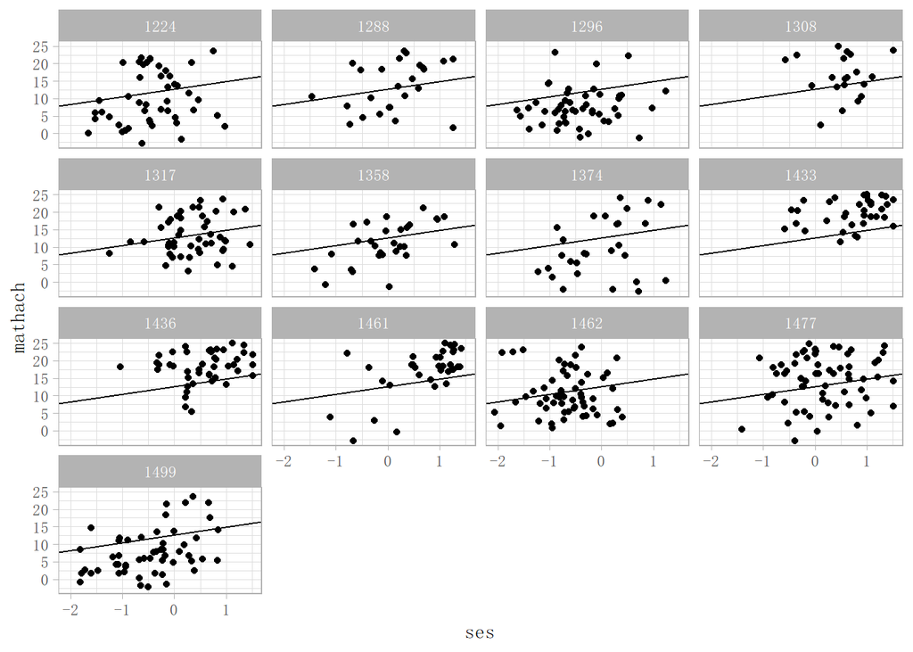

```r
hsb %>%
  # mutate(pts = fitted(model_q3, level = 0, asList = FALSE)) %>%
  filter(schoolid < 1500) %>%
  ggplot(aes(x = ses, y = mathach)) +
  geom_point() +
  # geom_smooth(method = "lm", se = FALSE) +
  geom_abline(slope = 2.19 , intercept = 12.68) +
  facet_wrap(~schoolid) +
  theme_textbook() +
  scale_color_uchicago()
```

**4) Now create a graph that estimates a unique regression line for each school. (Hint: use the following command twoway (scatter outcome predictor) (lfit outcome predictor, sort) if slimit==1, by(clusterID). Copy and paste your plot below. Does seeing this plot change you answer to the previous question?**

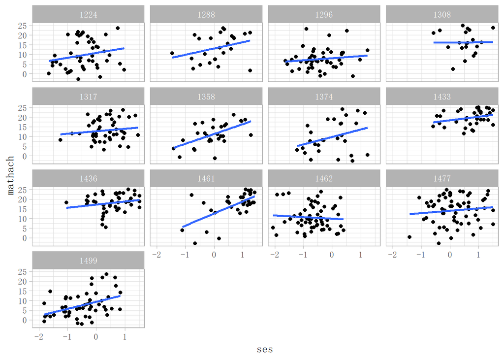

```r
model_q4 <- hsb %>%
  lmer(mathach ~ 1 + ses  + (1 | schoolid), data = .)

hsb %>%
  # mutate(pts = fitted(model_q4, level = 0, asList = FALSE)) %>%
  filter(schoolid < 1500) %>%
  ggplot(aes(x = ses, y = mathach)) +
  geom_point() +
  geom_smooth(method = "lm", se = FALSE) +
  facet_wrap(~schoolid) +
  theme_textbook() +
  scale_color_uchicago()
```

**5) To allow for schools to vary around both the intercept (i.e., the grand mean mathach score) and slope (i.e., average effect of within-school ses on mathach), fit a random-coefficient model:**

```r
model_q5 <- hsb %>%
  group_by(schoolid) %>%
  mutate(sch_m_ses = mean(ses) ) %>%
  center(ses, mean(ses)) %>%
  ungroup() %>%
  lmer(mathach ~ 1 + ses + sch_m_ses + (1 + ses | schoolid), data = .)

tab_model(model_q5)
```

|  | mathach |  |  |
| --- | --- | --- | --- |
| Predictors | Estimates | CI | p |
| (Intercept) | 12.68 | 12.39 – 12.97 | **<0.001** |
| ses | 2.19 | 1.94 – 2.44 | **<0.001** |
| sch m ses | 5.90 | 5.19 – 6.60 | **<0.001** |
| Random Effects |  |  |  |
| σ<sup>2</sup> | 36.71 |  |  |
| τ<sub>00</sub> <sub>schoolid</sub> | 2.69 |  |  |
| τ<sub>11</sub> <sub>schoolid.ses</sub> | 0.69 |  |  |
| ρ<sub>01</sub> <sub>schoolid</sub> | -0.19 |  |  |
| ICC <sub>schoolid</sub> | 0.07 |  |  |
| Observations | 7185 |  |  |
| Marginal R<sup>2</sup> / Conditional R<sup>2</sup> | 0.168 / 0.231 |  |  |

**Save your estimated model coefficients from the random-coefficient model.**

(Hint: use the following command in Stata: estimates store rand_coef).

**Construct a 95% prediction interval for the school slopes**

```r
slopes_CI <- function(estimate, variance) {

  ub<-estimate + (1.96*sqrt(variance))
  lb<-estimate - (1.96*sqrt(variance))
  print(paste("UB is", round(ub,3), "LB is", round(lb,3)))
}

slopes_CI(2.19, 0.69)
```

```
## [1] "UB is 3.818 LB is 0.562"
```

What does this prediction interval tell you?

**6) We can empircally test whether or not we need to model the random slope by using a naiive likelihood-ratio test. The null hypothesis, that the variation of the slope is equal to 0, is tested against the alternative hypothesis, that the variation of the slope is greater than 0. Report the estimated p-value and interpret the results. (Hint: use the following command in Stata: lrtest rand_int rand_coef, stats)**

```r
anova(model_q4, model_q5, test = "Chisq")
```

|  | Df | AIC | BIC | logLik | deviance | Chisq | Chi Df | Pr(>Chisq) |
| --- | --- | --- | --- | --- | --- | --- | --- | --- |
| model_q4 | 4 | 46649.00 | 46676.52 | -23320.50 | 46641.00 | NA | NA | NA |
| model_q5 | 7 | 46567.19 | 46615.34 | -23276.59 | 46553.19 | 87.81894 | 3 | 6.441059e-19 |

**7) We want to know if the association between a student’s ses and their math achievement, which we found varied significantly across schools, can be further predicted by their school’s sector (public vs. private), as shown in the following model:**

```r
model_q7 <- hsb %>%
  group_by(schoolid) %>%
  mutate(sch_m_ses = mean(ses) ) %>%
  center(ses, mean(ses)) %>%
  ungroup() %>%
  lmer(mathach ~ 1 + ses*sector + sch_m_ses + (1 + ses | schoolid), data = .)

tab_model(model_q7)
```

|  | mathach |  |  |
| --- | --- | --- | --- |
| Predictors | Estimates | CI | p |
| (Intercept) | 12.12 | 11.73 – 12.51 | **<0.001** |
| ses | 2.79 | 2.48 – 3.09 | **<0.001** |
| sector | 1.25 | 0.65 – 1.85 | **<0.001** |
| sch m ses | 5.25 | 4.52 – 5.97 | **<0.001** |
| ses:sector | -1.35 | -1.81 – -0.89 | **<0.001** |
| Random Effects |  |  |  |
| σ<sup>2</sup> | 36.71 |  |  |
| τ<sub>00</sub> <sub>schoolid</sub> | 2.38 |  |  |
| τ<sub>11</sub> <sub>schoolid.ses</sub> | 0.27 |  |  |
| ρ<sub>01</sub> <sub>schoolid</sub> | 0.24 |  |  |
| ICC <sub>schoolid</sub> | 0.06 |  |  |
| Observations | 7185 |  |  |
| Marginal R<sup>2</sup> / Conditional R<sup>2</sup> | 0.176 / 0.228 |  |  |

Does this model fit the data better than the model without sector (makesure to store the estimates of this model using estimates store)? How much variance in the random slope is explained by the inclusion of sectorin the equation for beta1 relative to the model in question 5?

Interpret the interaction coefficient.

**Extra credit: Graph the interaction**

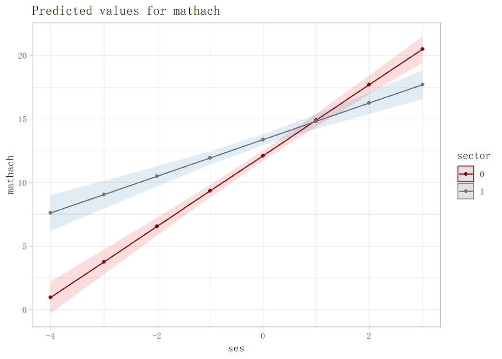

```r
# hsb %>%
#   mutate(pts = fitted(model_q7, level = 0, asList = FALSE)) %>%
#   ggplot(aes(x = ses, y = pts, color = sector)) +
#
#

sjPlot::plot_model(model_q7, type = "pred", terms = c("ses", "sector")) + theme_textbook() + scale_color_uchicago() + geom_point()
```